# Assignment_Q2_FINAL

Abhishek, Manav, Gaurav & Suman

15/12/2018

# Final Assignment Question 2

In this question, we simulate the random movement of the Stock Price using the log normal random variables in r with the function *rlnorm*. This help us simulate the stock price movement over the next 30 days using the Geometric Brownian Motion formula.

## Part 1

The first part of this question deals with showing that when the implied volatility is the same as the realized volatility, Gamma and Theta neutralize each other, i.e.

$$0.5*\Gamma(\Delta S)^{2} + \Theta (dT) \approx 0$$

```r
S <- 100
K <- 100
#Part [1]
sigma <- 0.3 # realized vol can be 0.3 for [1] or 0.5 for [2]
drift <- 0 # drift = r - q
N <- 30
timestep <- 1 / 250
p1 <- (drift - 0.5 * sigma * sigma) * timestep
p2 <- sigma * sqrt(timestep)
# ss is the simulated price movement for N days
ss <- rep(S, N) * cumprod(rlnorm(N, mean = p1, sd = p2))
df <- data_frame(S = ss, days = 1:N)
opt <- df %>%
  rowwise() %>%
  mutate(price = GBSOption("c", S = S, X = 100, Time = (N+1-days) / 250, r = 0, b = 0, sigma = 0.3)@price,
          delta = GBSGreeks("Delta", "c", S = S, X = 100, Time = (N+1-days) / 250, r = 0, b = 0, sigma = 0.3),
          gamma = GBSGreeks("Gamma", "c", S = S, X = 100, Time = (N+1-days) / 250, r = 0, b = 0, sigma = 0.3),
          theta = GBSGreeks("Theta", "c", S = S, X = 100, Time = (N+1-days) / 250, r = 0, b = 0, sigma = 0.3)) %>%
  ungroup()

opt1 <- opt %>%
  mutate(stock_price_change = c(0,diff(S)),
         price_change = c(0,diff(price)),
         approx = delta * stock_price_change + 0.5 * gamma * (stock_price_change) ** 2 + theta * 1/250,
         gt_neutralise = 0.5 * gamma * (price_change) ** 2 + theta * 1/250) %>%
  mutate(gt_neutralise = ifelse(gt_neutralise<0.001, 0, gt_neutralise))

knitr::kable(opt1 %>% select(S, days, price, stock_price_change, price_change, approx, gamma, theta, gt_neutralise), format="html", caption="Gamma and Theta neutralise (gt_neutralise)") %>%
  kable_styling(bootstrap_options = c("striped", "hover", "responsive")) %>%
  column_spec(9, bold = T, color = "white", background = "#D7261E")
```

Gamma and Theta neutralise (gt_neutralise)

| S | days | price | stock_price_change | price_change | approx | gamma | theta | gt_neutralise |
| --- | --- | --- | --- | --- | --- | --- | --- | --- |
| 100.28411 | 1 | 4.293562 | 0.0000000 | 0.0000000 | -0.0690778 | 0.0381594 | -17.269455 | 0.0000000 |
| 105.01748 | 2 | 7.155377 | 4.7333763 | 2.8618148 | 3.6206880 | 0.0323035 | -16.031899 | 0.0681549 |
| 103.23004 | 3 | 5.885410 | -1.7874401 | -1.2699671 | -1.1610939 | 0.0359876 | -17.257492 | 0.0000000 |
| 101.07170 | 4 | 4.511556 | -2.1583469 | -1.3738543 | -1.1947689 | 0.0395427 | -18.177658 | 0.0000000 |
| 102.75773 | 5 | 5.443690 | 1.6860315 | 0.9321344 | 1.0425217 | 0.0380079 | -18.059884 | 0.0000000 |
| 103.57941 | 6 | 5.902085 | 0.8216778 | 0.4583950 | 0.4847325 | 0.0372005 | -17.960081 | 0.0000000 |
| 103.15021 | 7 | 5.547913 | -0.4292012 | -0.3541727 | -0.3487270 | 0.0387081 | -18.533357 | 0.0000000 |
| 104.45141 | 8 | 6.351986 | 1.3012077 | 0.8040738 | 0.8698405 | 0.0365873 | -17.962696 | 0.0000000 |
| 105.27283 | 9 | 6.869533 | 0.8214162 | 0.5175462 | 0.5439245 | 0.0350953 | -17.502247 | 0.0000000 |
| 105.83719 | 10 | 7.220568 | 0.5643589 | 0.3510355 | 0.3638995 | 0.0340280 | -17.152406 | 0.0000000 |
| 109.22242 | 11 | 9.906754 | 3.3852340 | 2.6861859 | 2.9984920 | 0.0239708 | -12.868220 | 0.0350089 |
| 103.64079 | 12 | 5.487874 | -5.5816285 | -4.4188798 | -3.2399480 | 0.0416021 | -20.108966 | 0.3257363 |
| 101.66851 | 13 | 4.139710 | -1.9722830 | -1.3481639 | -1.1736315 | 0.0472950 | -21.998891 | 0.0000000 |
| 103.06802 | 14 | 4.935342 | 1.3995099 | 0.7956313 | 0.8881295 | 0.0451976 | -21.606046 | 0.0000000 |
| 100.82828 | 15 | 3.471629 | -2.2397436 | -1.4637130 | -1.2154414 | 0.0515760 | -23.595259 | 0.0000000 |
| 101.10486 | 16 | 3.532440 | 0.2765804 | 0.0608115 | 0.0636425 | 0.0527724 | -24.275237 | 0.0000000 |
| 100.46976 | 17 | 3.079324 | -0.6351009 | -0.4531163 | -0.4331072 | 0.0556444 | -25.275809 | 0.0000000 |
| 100.04749 | 18 | 2.753124 | -0.4222656 | -0.3262002 | -0.3177997 | 0.0582389 | -26.232412 | 0.0000000 |
| 101.89166 | 19 | 3.699074 | 1.8441720 | 0.9459504 | 1.1426188 | 0.0566335 | -26.458364 | 0.0000000 |
| 102.00609 | 20 | 3.663493 | 0.1144235 | -0.0355815 | -0.0364706 | 0.0585161 | -27.399332 | 0.0000000 |
| 101.09298 | 21 | 2.992233 | -0.9131063 | -0.6712596 | -0.6244199 | 0.0643212 | -29.580715 | 0.0000000 |
| 100.43583 | 22 | 2.500013 | -0.6571458 | -0.4922201 | -0.4670405 | 0.0694003 | -31.502933 | 0.0000000 |
| 101.08024 | 23 | 2.735351 | 0.6444033 | 0.2353380 | 0.2631404 | 0.0716727 | -32.953298 | 0.0000000 |
| 100.12920 | 24 | 2.069029 | -0.9510337 | -0.6663218 | -0.6019920 | 0.0792662 | -35.762035 | 0.0000000 |
| 99.42587 | 25 | 1.575724 | -0.7033365 | -0.4933054 | -0.4550742 | 0.0858982 | -38.211600 | 0.0000000 |
| 101.09130 | 26 | 2.302701 | 1.6654335 | 0.7269770 | 0.9739386 | 0.0895145 | -41.165517 | 0.0000000 |
| 104.24890 | 27 | 4.516554 | 3.1576001 | 2.2138535 | 2.9037695 | 0.0541304 | -26.472590 | 0.0267601 |
| 107.64975 | 28 | 7.664480 | 3.4008474 | 3.1479254 | 3.3927517 | 0.0087829 | -4.580092 | 0.0251962 |
| 104.65197 | 29 | 4.702838 | -2.9977758 | -2.9616417 | -2.7830917 | 0.0330392 | -16.283102 | 0.0797664 |
| 103.89147 | 30 | 3.907365 | -0.7605039 | -0.7954729 | -0.7874395 | 0.0262273 | -12.738708 | 0.0000000 |

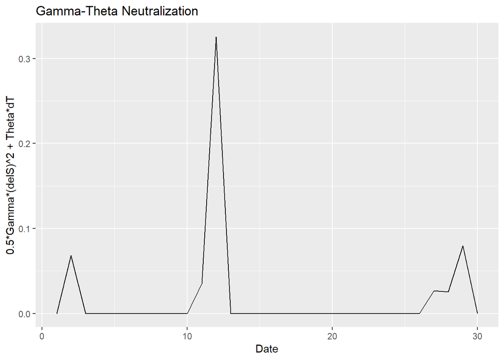

```r
ggplot(opt1) + geom_line(aes(x=days, y=gt_neutralise)) +  labs(title = "Gamma-Theta Neutralization", x = "Date", y = "0.5*Gamma*(delS)^2 + Theta*dT")
```